# Multidimensional Cointegration

Oliver Schwartz

4/28/2021

## Getting data

```r
# Constants.
SYMS <- c("GEH1", "GEM1", "GEU1", "GEZ1", "GEH2", "GEM2", "GEU2", "GEZ2")
DATE <- "2020.10.05"
NSEC <- 23 * 3600
TMIN <- "-0D07:00:00"

# Get midpoint data for all symbols.
mid_by_sym <- list()
for (sym in SYMS) {
  q1 <- sprintf("([] time:%s+1000000000 * til %d)", TMIN, NSEC)
  q2 <- sprintf(
    "select time, mid:0.5*(bid+ask) from quote where sym=`%s, date=%s",
    sym, DATE
  )
  q3 <- sprintf("aj[`time; %s; %s]", q1, q2)
  mid_by_sym[[sym]] <- try_execute(q3)
}
```

Let’s plot `GEH1` and `GEZ1` to visualize the price relationship. Eurodollars are a large tick asset (with deep order books) so we might expect very minimal price fluctuations.

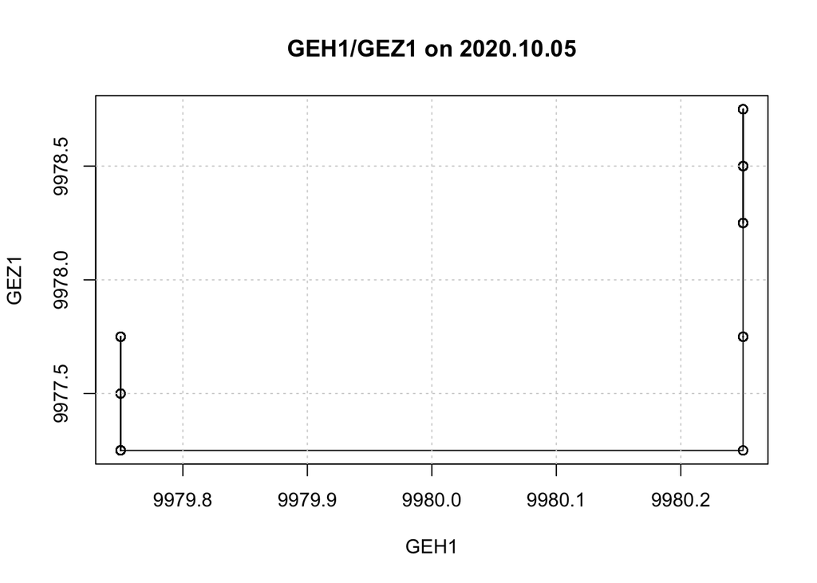

```r
plot(mid_by_sym[["GEH1"]]$mid, mid_by_sym[["GEZ1"]]$mid, type="o",
     main=sprintf("GEH1/GEZ1 on %s", DATE), xlab="GEH1", ylab="GEZ1")
grid()
```

## Rolling statistics

Our assumption is that all 8 prices move back and forth along a 1-dimensional line. (We will all take more degrees of freedom, for instance, we might assume the prices move along a 2d-plane in $\mathbb{R}^8$.)

We need to compute exponential rolling averages using a 1-hour window time.

How do we compute an exponential rolling average? At a time $n$, the exponential average is given by $A_n / B_n$ where:
$$\begin{align*}
A_n &= \sum_{j=1}^n e^{-(n-j) / m} x_j \\
B_n &= \sum_{j=1}^n e^{-(n-j) / m}
\end{align*}$$

This yields the following recursive update rules, which makes this computation constant at every time step, i.e. O(1).
$$\begin{align*}
A_n &= e^{-(n-j) / m} x_j = x_n + \sum_{j=1}^{n-1}e^{-(n-j) / m} x_j \\
&= x_n + e^{-1/m} \cdot \sum_{j=1}^{n-1}e^{-(n-j-1) / m} x_j \\
&= x_n + e^{-1/m} \cdot A_{n-1}
\end{align*}$$
Similarly, for $B_n$:
$$B_n = 1 + e^{-1/m}\cdot B_{n-1}$$

```r
# Compute the rolling statistics for a time series.
# Returns a list with:
# - ema: exponentially weighted average for given window size.
# - std: rectangular standard deviation for given window size.
rolling_stats <- function(x, y, wlen) {

  # Initialize values to compute exp mean, exp std.
  N <- length(x)
  ema_x <- c(x[1])      # Exponential average.
  ema_y <- c(y[1])
  rectmean_x <- c(x[1]) # Rectangular mean (for below two quantities).
  rectmean_y <- c(y[1])
  sqr_x <- c(x[1]**2)   # Rectangular mean of squared prices.
  sqr_y <- c(x[1]**2)
  std_x <- c(0)         # Rectangular standard deviation.
  std_y <- c(0)
  prcx_prcy <- c(x[1] * y[1])
  corr <- c(NA)

  # For ema calculation.
  A_x <- x[1]
  A_y <- y[1]
  B_x <- 1
  B_y <- 1

  for (t in 2:N) {

    # EMA updates.
    A_x <- x[t] + exp(-1 / wlen) * A_x
    A_y <- y[t] + exp(-1 / wlen) * A_y
    B_x <- 1 + exp(-1 / wlen) * B_x
    B_y <- 1 + exp(-1 / wlen) * B_y
    ema_x[t] <- A_x / B_x
    ema_y[t] <- A_y / B_y

    # If we have seen a window's worth of data.
    if (t > wlen) {
      rectmean_x[t] <- (x[t] + wlen*rectmean_x[t-1] - x[t-wlen]) / wlen
      rectmean_y[t] <- (y[t] + wlen*rectmean_y[t-1] - y[t-wlen]) / wlen
      sqr_x[t] <- (x[t]**2 + wlen*sqr_x[t-1] - x[t-wlen]**2) / wlen
      sqr_y[t] <- (y[t]**2 + wlen*sqr_y[t-1] - y[t-wlen]**2) / wlen
      prcx_prcy[t] <- (
        x[t]*y[t] + wlen*prcx_prcy[t-1] - x[t-wlen]*y[t-wlen]
        ) / wlen
    }

    # We haven't seen a window's worth of data (only t-1 prior values).
    else {
      rectmean_x[t] <- (x[t] + (t-1)*rectmean_x[t-1]) / t
      rectmean_y[t] <- (y[t] + (t-1)*rectmean_y[t-1]) / t
      sqr_x[t] <- (x[t]**2 + (t-1)*sqr_x[t-1]) / t
      sqr_y[t] <- (y[t]**2 + (t-1)*sqr_y[t-1]) / t
      prcx_prcy[t] <- (x[t]*y[t] + (t-1)*prcx_prcy[t-1]) / t
    }

    # Compute standard deviation and correlation.
    std_x[t] <- sqrt(sqr_x[t] - rectmean_x[t]**2)
    std_y[t] <- sqrt(sqr_y[t] - rectmean_y[t]**2)
    corr[t] <- (prcx_prcy[t] - rectmean_x[t]*rectmean_y[t]) / (std_x[t]*std_y[t])
  }

  return(list(
    corr=corr,
    ema_x=ema_x,
    ema_y=ema_y,
    rectmean_x=rectmean_x,
    rectmean_y=rectmean_y
  ))
}

rolling_stats(c(1,2,3), c(1,2,3), wlen=2)
```

```
## $corr
## [1] NA  1  1
##
## $ema_x
## [1] 1.000000 1.622459 2.320157
##
## $ema_y
## [1] 1.000000 1.622459 2.320157
##
## $rectmean_x
## [1] 1.0 1.5 2.5
##
## $rectmean_y
## [1] 1.0 1.5 2.5
```

For every unique pair of instruments, compute their rolling statistics and their rolling correlation.

```r
pairwise_stats <- list()
WINDOW_LEN <- 3600

# for (i in 1:(length(SYMS)-1)) {
#   for (j in (i+1):length(SYMS)) {
#     key <- paste0(SYMS[i], ",", SYMS[j])
#     pairwise_stats[[key]] <- rolling_stats(
#       x=mid_by_sym[[SYMS[i]]]$mid,
#       y=mid_by_sym[[SYMS[j]]]$mid,
#       wlen=WINDOW_LEN
#     )
#     break
#   }
#   break
# }
```

At each point in time, we compute the SVD of the covariance matrix. We compute a forecast price $P_*$, the projection of the actual price $P$ onto the first principal component of the covariance matrix.